# Produce 101 seasons 1 & 2 data analysis

# Produce 101

## Introduction

- Produce 101 is a korean survival reality show on Mnet.
- It is a large-scale project in which the public (called ‘national producers’) “produces” a unit group by choosing 11 members among 101 trainees from over 50 entertainment companies.
- The show has 11 episodes.
- In the first two episodes, the trainees’ are ranked by judges from A to E based on their perfromance which determines their position in the first trailor. And in each episode, their ranking are calculated by votings by viewers, the bottom ones are eliminated.
- There are different votings based on their performance in different tasks.
- Season 1 consist of all girls while season 2 is all boys.
- This project aims to explore which kind of trainees are more likely to debut.

## Packages

```r
library(readxl)
library(rvest)
library(ggplot2)
library(tidyverse)
library(gridExtra)
library(stringr)
library(ggvis)
library(ggbio)
library(knitr)
library(kableExtra)
library(dplyr)
library(plotly)
```

# Cleaning data

## Data

- Data from webpage (Wikipedia)
- https://en.wikipedia.org/wiki/List_of_Produce_101_contestants
- https://en.wikipedia.org/wiki/List_of_Produce_101_Season_2_contestants
- Korean TV show produce 101, seasons 1 and 2
- Tables for overall rank & performances for different tasks

## get data from web

[output not shown]

[output cut: 401 more lines]

# Clean data (function)

- Cleaned name of trainees
- Changed type of age and ranking to integers
- Assigned evaluation numeric values

```
##                          Company             Name Age Evaluation1
## 1             Individual Trainee      Kang Si-won  20           F
## 2             Individual Trainee     Kim Min-jung  14           D
## 3             Individual Trainee   Kim Seo-kyoung  17           B
## 4             Individual Trainee     Kim Si-hyeon  17           F
## 5             Individual Trainee    Seong Hye-min  27           D
## 6          &August Entertainment  Yoon Seo-hyeung  21           F
## 7                      101 Doors       Kim Ha-yun  22           F
## 8                  2able Company   Park Hae-young  18           A
## 9           Astory Entertainment      Park Ga-eul  17           B
## 10          Astory Entertainment     Yim Kyung-ha  19           A
## 11        Blessing Entertainment       Kim Do-hee  19           F
## 12        Blessing Entertainment       Kim Sol-ee  15           F
## 13        Blessing Entertainment    Bang Joon-hee  18           F
## 14        Blessing Entertainment        Ahn Yu-mi  19           D
```

[output cut: 393 more lines]

## Combine tables

- Combine table containing info about height, weight and training time

## Calculations

- Calculate training time(months) from training month & year.

## Combine to one big df

### Data table season 1

| Company | Name | Age | Evaluation1 | Evaluation2 | Ranking_ep1 | Ranking_ep2 | Ranking_ep3 | Ranking_ep5 | Votes_ep5 | Ranking_ep6 | Ranking_ep8 | Votes_ep8 | Ranking_ep10 | Votes_ep10 | Ranking_ep11 | Votes_ep11 | Ranking_final | evaluation1_num | evaluation2_num | Gender | Height | Training_time_years | Training_time_month | Weight | Training_time | Evaluation_diff |
| --- | --- | --- | --- | --- | --- | --- | --- | --- | --- | --- | --- | --- | --- | --- | --- | --- | --- | --- | --- | --- | --- | --- | --- | --- | --- | --- |
| Individual Trainee | Kang Si-won | 20 | F | C | 46 | 45 | 39 | 39 | 56224 | 29 | 36 | 206504 | NA | NA | NA | NA | 36 | 5 | 3 | F | 173.0 | 2 | 0 | 53.0 | 24 | -2 |
| Individual Trainee | Kim Min-jung | 14 | D | F | 29 | 34 | 43 | 51 | 39033 | 39 | 45 | 127877 | NA | NA | NA | NA | 45 | 4 | 5 | F | 152.0 | 5 | 6 | 40.0 | 66 | 1 |
| Individual Trainee | Kim Seo-kyoung | 17 | B | A | 34 | 43 | 45 | 30 | 72474 | 22 | 27 | 300125 | 30 | 6871 | NA | NA | 30 | 2 | 1 | F | 155.0 | 2 | 0 | 42.0 | 24 | -1 |
| Individual Trainee | Kim Si-hyeon | 17 | F | D | 22 | 30 | 36 | 35 | 60090 | 37 | 40 | 150271 | NA | NA | NA | NA | 40 | 5 | 4 | F | 154.0 | 0 | 4 | 43.0 | 4 | -1 |
| Individual Trainee | Kim Si-hyeon | 17 | F | D | 22 | 30 | 36 | 35 | 60090 | 37 | 40 | 150271 | NA | NA | NA | NA | 40 | 5 | 4 | F | 168.0 | 1 | 0 | 49.0 | 12 | -1 |
| Individual Trainee | Seong Hye-min | 27 | D | F | 39 | 51 | 53 | 55 | 33641 | 25 | 24 | 329366 | 28 | 7129 | NA | NA | 28 | 4 | 5 | F | 169.0 | 5 | 2 | 51.0 | 62 | 1 |
| &August Entertainment | Yoon Seo-hyeung | 21 | F | D | 58 | 25 | 22 | 29 | 73558 | 35 | 37 | 187021 | NA | NA | NA | NA | 37 | 5 | 4 | F | 163.0 | 0 | 2 | 44.0 | 2 | -1 |
| 101 Doors | Kim Ha-yun | 22 | F |  | 93 | 56 | NA | NA | NA | NA | NA | NA | NA | NA | NA | NA | NA | 5 | 0 | F | 158.0 | 2 | 6 | 46.0 | 30 | -5 |
| 2able Company | Park Hae-young | 18 | A | B | 97 | 81 | 79 | 43 | 47662 | 38 | 38 | 172797 | NA | NA | NA | NA | 38 | 1 | 2 | F | 165.0 | 1 | 0 | 57.0 | 12 | 1 |
| Astory Entertainment | Park Ga-eul | 17 | B | C | 87 | 100 | 75 | 46 | 41873 | 51 | 52 | 103784 | NA | NA | NA | NA | 52 | 2 | 3 | F | 164.0 | 0 | 6 | 48.0 | 6 | 1 |
| Astory Entertainment | Yim Kyung-ha | 19 | A |  | 88 | 48 | NA | NA | NA | NA | NA | NA | NA | NA | NA | NA | NA | 1 | 0 | F | 164.0 | 0 | 6 | 41.0 | 6 | -1 |
| Blessing Entertainment | Kim Do-hee | 19 | F | F | 48 | 68 | 70 | 81 | 21485 | NA | NA | NA | NA | NA | NA | NA | 81 | 5 | 5 | F | 165.0 | 0 | 8 | 47.0 | 8 | 0 |
| Blessing Entertainment | Kim Sol-ee | 15 | F | F | 98 | 95 | 96 | 92 | 19899 | NA | NA | NA | NA | NA | NA | NA | 92 | 5 | 5 | F | 172.7 | 1 | 2 | 53.0 | 14 | 0 |
| Blessing Entertainment | Bang Joon-hee | 18 | F | C | 73 | 88 | 97 | 94 | 18579 | NA | NA | NA | NA | NA | NA | NA | 94 | 5 | 3 | F | 164.0 | 1 | 6 | 45.0 | 18 | -2 |
| Blessing Entertainment | Ahn Yu-mi | 19 | D | F | 92 | 98 | 90 | 63 | 27793 | NA | NA | NA | NA | NA | NA | NA | 63 | 4 | 5 | F | 168.0 | 1 | 2 | 50.0 | 14 | 1 |
| Blessing Entertainment | Oh Han-areum | 18 | F | F | 66 | 85 | 92 | 83 | 21245 | NA | NA | NA | NA | NA | NA | NA | 83 | 5 | 5 | F | 162.0 | 2 | 2 | 49.0 | 26 | 0 |
| Cani Star Entertainment | Park Ha-yi | 28 | F | D | 43 | 50 | 50 | 54 | 34459 | 45 | 51 | 106057 | NA | NA | NA | NA | 51 | 5 | 4 | F | 165.0 | 2 | 0 | 43.0 | 24 | -1 |
| Chorokbaem Juna | Ng Sze Kai | 22 | B | B | 53 | 52 | 19 | 17 | 176067 | 21 | 28 | 298495 | 23 | 14138 | NA | NA | 23 | 2 | 2 | F | 165.0 | 2 | 0 | 47.0 | 24 | 0 |
| Chungchun Music | Kang Si-ra | 25 | B | B | 42 | 60 | 62 | 59 | 29703 | 61 | 29 | 290109 | 16 | 26526 | 22 | 40759 | 22 | 2 | 2 | F | 161.0 | 4 | 4 | 45.0 | 52 | 0 |
| Clear Company | Ma Eun-jin | 19 | F | F | 65 | 36 | NA | NA | NA | NA | NA | NA | NA | NA | NA | NA | NA | 5 | 5 | F | 164.7 | 1 | 5 | 49.0 | 17 | 0 |
| CMG Chorok Stars | Lim Hyo-sun | 18 | D | F | 54 | 38 | NA | NA | NA | NA | NA | NA | NA | NA | NA | NA | NA | 4 | 5 | F | 170.0 | 6 | 0 | 54.0 | 72 | 1 |
| Cube Entertainment | Kwon Eun-bean | 16 | A | D | 10 | 10 | 12 | 16 | 179721 | 15 | 25 | 310972 | 35 | 2353 | NA | NA | 35 | 1 | 4 | F | 167.0 | 2 | 0 | 48.0 | 24 | 3 |
| Cube Entertainment | Lee Youn-seo | 14 | F | B | 18 | 21 | 29 | 38 | 56821 | 58 | 59 | 73702 | NA | NA | NA | NA | 59 | 5 | 2 | F | 162.0 | 1 | 6 | 43.0 | 18 | -3 |
| Cube Entertainment | Jeon So-yeon | 18 | A | A | 23 | 11 | 11 | 10 | 230395 | 18 | 19 | 372952 | 20 | 19045 | 20 | 78058 | 20 | 1 | 1 | F | 157.0 | 1 | 6 | 44.0 | 18 | 0 |
| DSP Media | Yun Chae-kyoung | 20 | D | C | 15 | 14 | 15 | 21 | 149977 | 20 | 15 | 460700 | 7 | 53255 | 16 | 128454 | 16 | 4 | 3 | F | 160.0 | 4 | 4 | 45.0 | 52 | -1 |
| DSP Media | Cho Shi-yoon | 20 | D | D | 21 | 15 | 17 | 27 | 102110 | 41 | 41 | 146681 | NA | NA | NA | NA | 41 | 4 | 4 | F | 160.0 | 4 | 4 | 43.0 | 52 | 0 |
| Duble Kick Company | Heo Chan-mi | 24 | A | B | 16 | 7 | 9 | 15 | 184926 | 28 | 33 | 249026 | 26 | 8571 | NA | NA | 26 | 1 | 2 | F | 161.0 | 10 | 4 | 45.0 | 124 | 1 |
| ECUBE Media | Kim Seol-a | 25 | D | F | 91 | 80 | 86 | 82 | 21394 | NA | NA | NA | NA | NA | NA | NA | 82 | 4 | 5 | F | 163.0 | 3 | 4 | 44.0 | 40 | 1 |
| Fantagio | Kim Do-yeon | 17 | B | A | 28 | 22 | 14 | 13 | 203007 | 8 | 7 | 841749 | 11 | 44873 | 8 | 200069 | 8 | 2 | 1 | F | 170.0 | 1 | 5 | 50.0 | 17 | -1 |
| Fantagio | Lee Soo-min | 17 | F | A | 89 | 87 | 77 | 45 | 43932 | 46 | 34 | 243513 | 31 | 6749 | NA | NA | 31 | 5 | 1 | F | 166.0 | 4 | 6 | 47.0 | 54 | -4 |

[output cut: 73 more lines]

### Data table season 2

| Company | Name | Age | Evaluation1 | Evaluation2 | Ranking_ep1 | Ranking_ep2 | Ranking_ep3 | Ranking_ep5 | Votes_ep5 | Ranking_ep6 | Ranking_ep8 | Votes_ep8 | Ranking_ep10 | Votes_ep10 | Ranking_ep11 | Votes_ep11 | Ranking_final | evaluation1_num | evaluation2_num | Gender | Height | Training_time_years | Training_time_month | Weight | Training_time | Evaluation_diff |
| --- | --- | --- | --- | --- | --- | --- | --- | --- | --- | --- | --- | --- | --- | --- | --- | --- | --- | --- | --- | --- | --- | --- | --- | --- | --- | --- |
| Individual Trainee | Kim Sang-been | 23 | B | A | 46 | 51 | 55 | 60 | 100142 | 39 | 48 | 379753 | NA | NA | NA | NA | 48 | 2 | 1 | M | 173 | 2 | 8 | 63 | 32 | -1 |
| Individual Trainee | Kim Jae-hwan | 22 | B | B | 27 | 18 | 18 | 16 | 569969 | 7 | 9 | 1822842 | 13 | 259776 | 4 | 1051735 | 4 | 2 | 2 | M | 175 | 4 | 2 | 61 | 50 | 0 |
| Individual Trainee | Kim Chan | 22 | D | F | 39 | 40 | 56 | 82 | 69967 | NA | NA | NA | NA | NA | NA | NA | 82 | 4 | 5 | M | 178 | 2 | 4 | 60 | 28 | 1 |
| Individual Trainee | Lee In-soo | 22 | C | B | 33 | 30 | 43 | 57 | 105599 | 56 | 57 | 256851 | NA | NA | NA | NA | 57 | 3 | 2 | M | 170 | 2 | 8 | 58 | 32 | -1 |
| Individual Trainee | Choi Dong-ha | 22 | C | B | 38 | 35 | 51 | 63 | 88032 | NA | NA | NA | NA | NA | NA | NA | 63 | 3 | 2 | M | 172 | 4 | 4 | 59 | 52 | -1 |
| 2able Company | Ju Won-tak | 22 | B | C | 92 | 83 | 94 | 62 | 88474 | NA | NA | NA | NA | NA | NA | NA | 62 | 2 | 3 | M | 178 | 4 | 2 | 60 | 50 | 1 |
| 2Y Entertainment | Lee Ki-won | 22 | D | D | 63 | 65 | 58 | 58 | 103065 | 46 | 53 | 318579 | NA | NA | NA | NA | 53 | 4 | 4 | M | 170 | 4 | 7 | 56 | 55 | 0 |
| Ardor and Able | Roh Tae-hyun | 25 | A | A | 61 | 48 | 24 | 26 | 353043 | 32 | 21 | 945314 | 25 | 143523 | NA | NA | 25 | 1 | 1 | M | 168 | 3 | 9 | 59 | 45 | 0 |
| Ardor and Able | Ha Seng-un | 24 | A | A | 34 | 28 | 23 | 21 | 459912 | 27 | 25 | 838649 | 3 | 413654 | 11 | 790302 | 11 | 1 | 1 | M | 168 | 2 | 3 | 57 | 27 | 0 |
| Banana Entertainment | Yoon Yong-bin | 23 | C | D | 80 | 73 | 67 | 73 | 77030 | NA | NA | NA | NA | NA | NA | NA | 73 | 3 | 4 | M | 178 | 1 | 2 | 65 | 14 | 1 |
| Blessing Entertainment | Yu Jin-won | 21 | C | F | 79 | 87 | 70 | 75 | 76303 | NA | NA | NA | NA | NA | NA | NA | 75 | 3 | 5 | M | 178 | 0 | 10 | 69 | 10 | 2 |
| Blessing Entertainment | Im Woo-hyeok | 24 | C | C | 49 | 53 | 57 | 66 | 86710 | NA | NA | NA | NA | NA | NA | NA | 66 | 3 | 3 | M | 172 | 3 | 3 | 55 | 39 | 0 |
| Brand New Music | Kim Dong-hyun | 20 | B | B | 42 | 46 | 35 | 39 | 163092 | 41 | 29 | 821551 | 28 | 125155 | NA | NA | 28 | 2 | 2 | M | 179 | 0 | 11 | 63 | 11 | 0 |
| Brand New Music | Park Woo-jin | 19 | A | A | 72 | 75 | 38 | 24 | 403690 | 16 | 14 | 1396889 | 6 | 372493 | 6 | 937379 | 6 | 1 | 1 | M | 174 | 1 | 2 | 60 | 14 | 0 |
| Brand New Music | Lee Dae-hwi | 17 | A | A | 3 | 3 | 2 | 7 | 809484 | 10 | 4 | 2095314 | 10 | 325990 | 3 | 1102005 | 3 | 1 | 1 | M | 172 | 2 | 4 | 53 | 28 | 0 |
| Brand New Music | Lim Young-min | 23 | B | A | 24 | 27 | 31 | 27 | 312983 | 12 | 5 | 2011798 | 17 | 197721 | 15 | 654505 | 15 | 2 | 1 | M | 181 | 1 | 2 | 66 | 14 | -1 |
| Brave Entertainment | Arredondo Samuel | 16 | A | A | 6 | 2 | 3 | 2 | 863861 | 17 | 16 | 1306508 | 5 | 378491 | 18 | 391529 | 18 | 1 | 1 | M | 174 | 5 | 3 | 54 | 63 | 0 |
| C2K Entertainment | Kim Seong-lee | 24 | B | A | 69 | 60 | 53 | 46 | 133494 | 51 | 47 | 395013 | NA | NA | NA | NA | 47 | 2 | 1 | M | 173 | 5 | 2 | 61 | 62 | -1 |
| C9 Entertainment | Bae Jin-young | 18 | C | F | 5 | 12 | 10 | 12 | 667298 | 14 | 12 | 1502905 | 4 | 389982 | 10 | 807749 | 10 | 3 | 5 | M | 175 | 0 | 10 | 62 | 10 | 2 |
| Choon Entertainment | Kim Shi-hyun | 20 | D | D | NA | NA | NA | NA | NA | NA | NA | NA | NA | NA | NA | NA | NA | 4 | 4 | M | 175 | 0 | 9 | 58 | 9 | 0 |
| Choon Entertainment | Jin Longguo | 22 | C | D | 44 | 49 | 37 | 34 | 195419 | 35 | 18 | 1190935 | 21 | 184303 | NA | NA | 21 | 3 | 4 | M | 175 | 1 | 6 | 57 | 18 | 1 |
| Cre.Ker Entertainment | Joo Hak-nyeon | 19 | F | F | 4 | 8 | 6 | 10 | 703391 | 9 | 10 | 1629176 | 18 | 197194 | 19 | 349040 | 19 | 5 | 5 | M | 174 | 2 | 1 | 58 | 25 | 0 |
| CS Entertainment | Cho Jin-hyung | 22 | D | B | 85 | 92 | 75 | 72 | 77924 | NA | NA | NA | NA | NA | NA | NA | 72 | 4 | 2 | M | 170 | 2 | 2 | 61 | 26 | -2 |
| Cube Entertainment | Lai Kuan-lin | 17 | D | F | 10 | 6 | 7 | 9 | 717275 | 5 | 2 | 2202665 | 20 | 188940 | 7 | 905875 | 7 | 4 | 5 | M | 181 | 0 | 6 | 63 | 6 | 1 |
| Cube Entertainment | Yu Seon-ho | 16 | F | F | 22 | 16 | 15 | 15 | 575027 | 11 | 13 | 1502513 | 16 | 209168 | 17 | 551745 | 17 | 5 | 5 | M | 178 | 0 | 6 | 56 | 6 | 0 |
| FENT | Lee Jun-woo | 20 | F | C | 30 | 36 | 33 | 41 | 157041 | 58 | 50 | 343252 | NA | NA | NA | NA | 50 | 5 | 3 | M | 184 | 0 | 11 | 65 | 11 | -2 |
| Fantagio | Ong Seong-wu | 23 | A | A | 8 | 4 | 4 | 4 | 819186 | 6 | 7 | 1998849 | 8 | 358656 | 5 | 984756 | 5 | 1 | 1 | M | 179 | 0 | 8 | 63 | 8 | 0 |
| FNC Entertainment | Yoo Hoe-seung | 23 | D | C | 43 | 39 | 49 | 56 | 109060 | 36 | 39 | 527138 | NA | NA | NA | NA | 39 | 4 | 3 | M | 174 | 0 | 5 | 64 | 5 | -1 |
| Gini Stars Entertainment | Kim Do-hyun | 26 | C | C | 86 | 69 | 86 | 92 | 64157 | NA | NA | NA | NA | NA | NA | NA | 92 | 3 | 3 | M | 171 | 4 | 4 | 61 | 52 | 0 |
| Gini Stars Entertainment | Park Hee-seok | 26 | D | C | 89 | 66 | 87 | 86 | 68008 | NA | NA | NA | NA | NA | NA | NA | 86 | 4 | 3 | M | 177 | 5 | 4 | 65 | 64 | -1 |

[output cut: 71 more lines]

### Combined table

| Company | Name | Age | Evaluation1 | Evaluation2 | Ranking_ep1 | Ranking_ep2 | Ranking_ep3 | Ranking_ep5 | Votes_ep5 | Ranking_ep6 | Ranking_ep8 | Votes_ep8 | Ranking_ep10 | Votes_ep10 | Ranking_ep11 | Votes_ep11 | Ranking_final | evaluation1_num | evaluation2_num | Gender | Height | Training_time_years | Training_time_month | Weight | Training_time | Evaluation_diff |
| --- | --- | --- | --- | --- | --- | --- | --- | --- | --- | --- | --- | --- | --- | --- | --- | --- | --- | --- | --- | --- | --- | --- | --- | --- | --- | --- |
| Individual Trainee | Kang Si-won | 20 | F | C | 46 | 45 | 39 | 39 | 56224 | 29 | 36 | 206504 | NA | NA | NA | NA | 36 | 5 | 3 | F | 173.0 | 2 | 0 | 53.0 | 24 | -2 |
| Individual Trainee | Kim Min-jung | 14 | D | F | 29 | 34 | 43 | 51 | 39033 | 39 | 45 | 127877 | NA | NA | NA | NA | 45 | 4 | 5 | F | 152.0 | 5 | 6 | 40.0 | 66 | 1 |
| Individual Trainee | Kim Seo-kyoung | 17 | B | A | 34 | 43 | 45 | 30 | 72474 | 22 | 27 | 300125 | 30 | 6871 | NA | NA | 30 | 2 | 1 | F | 155.0 | 2 | 0 | 42.0 | 24 | -1 |
| Individual Trainee | Kim Si-hyeon | 17 | F | D | 22 | 30 | 36 | 35 | 60090 | 37 | 40 | 150271 | NA | NA | NA | NA | 40 | 5 | 4 | F | 154.0 | 0 | 4 | 43.0 | 4 | -1 |
| Individual Trainee | Kim Si-hyeon | 17 | F | D | 22 | 30 | 36 | 35 | 60090 | 37 | 40 | 150271 | NA | NA | NA | NA | 40 | 5 | 4 | F | 168.0 | 1 | 0 | 49.0 | 12 | -1 |
| Individual Trainee | Seong Hye-min | 27 | D | F | 39 | 51 | 53 | 55 | 33641 | 25 | 24 | 329366 | 28 | 7129 | NA | NA | 28 | 4 | 5 | F | 169.0 | 5 | 2 | 51.0 | 62 | 1 |
| &August Entertainment | Yoon Seo-hyeung | 21 | F | D | 58 | 25 | 22 | 29 | 73558 | 35 | 37 | 187021 | NA | NA | NA | NA | 37 | 5 | 4 | F | 163.0 | 0 | 2 | 44.0 | 2 | -1 |
| 101 Doors | Kim Ha-yun | 22 | F |  | 93 | 56 | NA | NA | NA | NA | NA | NA | NA | NA | NA | NA | NA | 5 | 0 | F | 158.0 | 2 | 6 | 46.0 | 30 | -5 |
| 2able Company | Park Hae-young | 18 | A | B | 97 | 81 | 79 | 43 | 47662 | 38 | 38 | 172797 | NA | NA | NA | NA | 38 | 1 | 2 | F | 165.0 | 1 | 0 | 57.0 | 12 | 1 |
| Astory Entertainment | Park Ga-eul | 17 | B | C | 87 | 100 | 75 | 46 | 41873 | 51 | 52 | 103784 | NA | NA | NA | NA | 52 | 2 | 3 | F | 164.0 | 0 | 6 | 48.0 | 6 | 1 |
| Astory Entertainment | Yim Kyung-ha | 19 | A |  | 88 | 48 | NA | NA | NA | NA | NA | NA | NA | NA | NA | NA | NA | 1 | 0 | F | 164.0 | 0 | 6 | 41.0 | 6 | -1 |
| Blessing Entertainment | Kim Do-hee | 19 | F | F | 48 | 68 | 70 | 81 | 21485 | NA | NA | NA | NA | NA | NA | NA | 81 | 5 | 5 | F | 165.0 | 0 | 8 | 47.0 | 8 | 0 |
| Blessing Entertainment | Kim Sol-ee | 15 | F | F | 98 | 95 | 96 | 92 | 19899 | NA | NA | NA | NA | NA | NA | NA | 92 | 5 | 5 | F | 172.7 | 1 | 2 | 53.0 | 14 | 0 |
| Blessing Entertainment | Bang Joon-hee | 18 | F | C | 73 | 88 | 97 | 94 | 18579 | NA | NA | NA | NA | NA | NA | NA | 94 | 5 | 3 | F | 164.0 | 1 | 6 | 45.0 | 18 | -2 |
| Blessing Entertainment | Ahn Yu-mi | 19 | D | F | 92 | 98 | 90 | 63 | 27793 | NA | NA | NA | NA | NA | NA | NA | 63 | 4 | 5 | F | 168.0 | 1 | 2 | 50.0 | 14 | 1 |
| Blessing Entertainment | Oh Han-areum | 18 | F | F | 66 | 85 | 92 | 83 | 21245 | NA | NA | NA | NA | NA | NA | NA | 83 | 5 | 5 | F | 162.0 | 2 | 2 | 49.0 | 26 | 0 |
| Cani Star Entertainment | Park Ha-yi | 28 | F | D | 43 | 50 | 50 | 54 | 34459 | 45 | 51 | 106057 | NA | NA | NA | NA | 51 | 5 | 4 | F | 165.0 | 2 | 0 | 43.0 | 24 | -1 |
| Chorokbaem Juna | Ng Sze Kai | 22 | B | B | 53 | 52 | 19 | 17 | 176067 | 21 | 28 | 298495 | 23 | 14138 | NA | NA | 23 | 2 | 2 | F | 165.0 | 2 | 0 | 47.0 | 24 | 0 |
| Chungchun Music | Kang Si-ra | 25 | B | B | 42 | 60 | 62 | 59 | 29703 | 61 | 29 | 290109 | 16 | 26526 | 22 | 40759 | 22 | 2 | 2 | F | 161.0 | 4 | 4 | 45.0 | 52 | 0 |
| Clear Company | Ma Eun-jin | 19 | F | F | 65 | 36 | NA | NA | NA | NA | NA | NA | NA | NA | NA | NA | NA | 5 | 5 | F | 164.7 | 1 | 5 | 49.0 | 17 | 0 |
| CMG Chorok Stars | Lim Hyo-sun | 18 | D | F | 54 | 38 | NA | NA | NA | NA | NA | NA | NA | NA | NA | NA | NA | 4 | 5 | F | 170.0 | 6 | 0 | 54.0 | 72 | 1 |
| Cube Entertainment | Kwon Eun-bean | 16 | A | D | 10 | 10 | 12 | 16 | 179721 | 15 | 25 | 310972 | 35 | 2353 | NA | NA | 35 | 1 | 4 | F | 167.0 | 2 | 0 | 48.0 | 24 | 3 |
| Cube Entertainment | Lee Youn-seo | 14 | F | B | 18 | 21 | 29 | 38 | 56821 | 58 | 59 | 73702 | NA | NA | NA | NA | 59 | 5 | 2 | F | 162.0 | 1 | 6 | 43.0 | 18 | -3 |
| Cube Entertainment | Jeon So-yeon | 18 | A | A | 23 | 11 | 11 | 10 | 230395 | 18 | 19 | 372952 | 20 | 19045 | 20 | 78058 | 20 | 1 | 1 | F | 157.0 | 1 | 6 | 44.0 | 18 | 0 |
| DSP Media | Yun Chae-kyoung | 20 | D | C | 15 | 14 | 15 | 21 | 149977 | 20 | 15 | 460700 | 7 | 53255 | 16 | 128454 | 16 | 4 | 3 | F | 160.0 | 4 | 4 | 45.0 | 52 | -1 |
| DSP Media | Cho Shi-yoon | 20 | D | D | 21 | 15 | 17 | 27 | 102110 | 41 | 41 | 146681 | NA | NA | NA | NA | 41 | 4 | 4 | F | 160.0 | 4 | 4 | 43.0 | 52 | 0 |
| Duble Kick Company | Heo Chan-mi | 24 | A | B | 16 | 7 | 9 | 15 | 184926 | 28 | 33 | 249026 | 26 | 8571 | NA | NA | 26 | 1 | 2 | F | 161.0 | 10 | 4 | 45.0 | 124 | 1 |
| ECUBE Media | Kim Seol-a | 25 | D | F | 91 | 80 | 86 | 82 | 21394 | NA | NA | NA | NA | NA | NA | NA | 82 | 4 | 5 | F | 163.0 | 3 | 4 | 44.0 | 40 | 1 |
| Fantagio | Kim Do-yeon | 17 | B | A | 28 | 22 | 14 | 13 | 203007 | 8 | 7 | 841749 | 11 | 44873 | 8 | 200069 | 8 | 2 | 1 | F | 170.0 | 1 | 5 | 50.0 | 17 | -1 |
| Fantagio | Lee Soo-min | 17 | F | A | 89 | 87 | 77 | 45 | 43932 | 46 | 34 | 243513 | 31 | 6749 | NA | NA | 31 | 5 | 1 | F | 166.0 | 4 | 6 | 47.0 | 54 | -4 |

[output cut: 174 more lines]

# Analysis of single variable

## Methods

- analyze_variable: analyze single variable. Output a list of two tables: cut the variable into 4 intervals; calculate average by gender. For example: analyze_variable(“Age”).
- graph_variable: bar plot of single variable by gender, and frequncy comparison. In both ggplot and plotly. For example: graph_variable(“Age”).

## Age of trainees

### Distribution

```
## [[1]]
## # A tibble: 4 x 2
##   `cut_width(Age, range/4)`     n
##                      <fctr> <int>
## 1                   [14,18]    55
## 2                   (18,22]    93
## 3                   (22,26]    49
## 4                   (26,30]     7
```

```
## [[1]]
## # A tibble: 2 x 2
##   Gender     mean
##    <chr>    <dbl>
## 1      F 19.49515
## 2      M 21.79208
```

### Graph

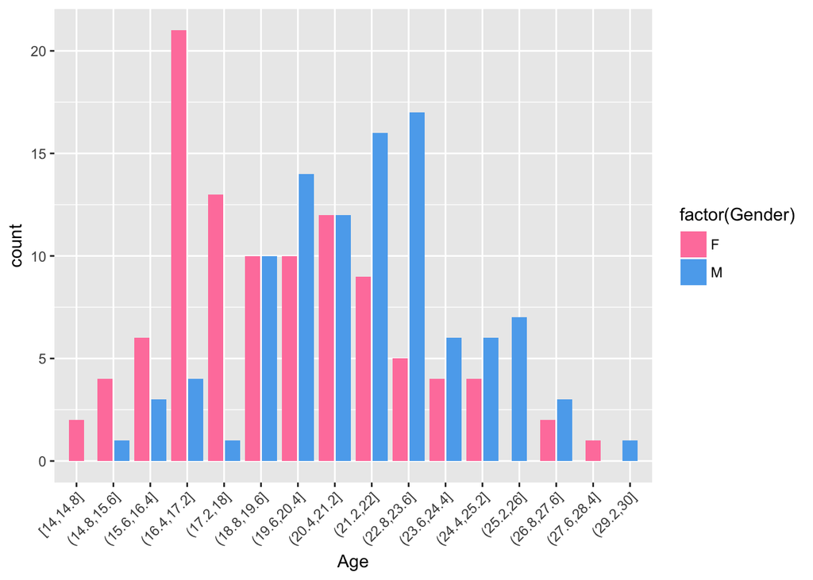

## Height of trainees

### Distribution

```
## [[1]]
## # A tibble: 5 x 2
##   `cut_width(Height, range/4)`     n
##                         <fctr> <int>
## 1                    [144,153]     1
## 2                    (153,162]    29
## 3                    (162,171]    80
## 4                    (171,179]    63
## 5                    (179,188]    31
```

```
## [[1]]
## # A tibble: 2 x 2
##   Gender     mean
##    <chr>    <dbl>
## 1      F 164.0680
## 2      M 176.4455
```

### Graph

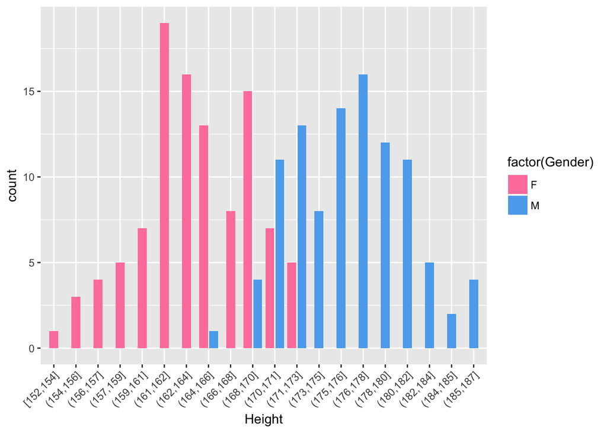

## Weight of trainees

### Distribution

```
## [[1]]
## # A tibble: 5 x 2
##   `cut_width(Weight, range/4)`     n
##                         <fctr> <int>
## 1                  [31.5,40.5]     2
## 2                  (40.5,49.5]    80
## 3                  (49.5,58.5]    47
## 4                  (58.5,67.5]    67
## 5                  (67.5,76.5]     8
```

```
## [[1]]
## # A tibble: 2 x 2
##   Gender     mean
##    <chr>    <dbl>
## 1      F 47.25340
## 2      M 61.35644
```

### Graph

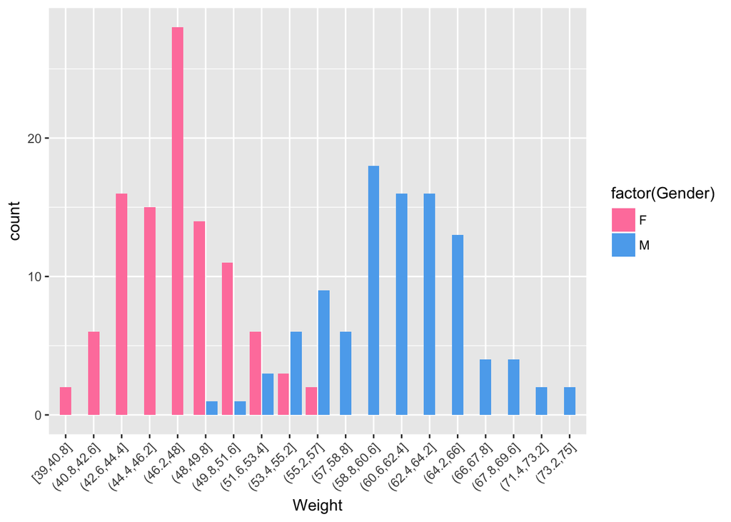

## Training time of trainees

### Distribution

```
## [[1]]
## # A tibble: 5 x 2
##   `cut_width(Training_time, range/4)`     n
##                                <fctr> <int>
## 1                        [-15.2,15.2]    71
## 2                         (15.2,45.8]    81
## 3                         (45.8,76.2]    43
## 4                          (76.2,107]     7
## 5                           (107,137]     2
```

```
## [[1]]
## # A tibble: 2 x 2
##   Gender     mean
##    <chr>    <dbl>
## 1      F 31.26214
## 2      M 30.39604
```

### Graph

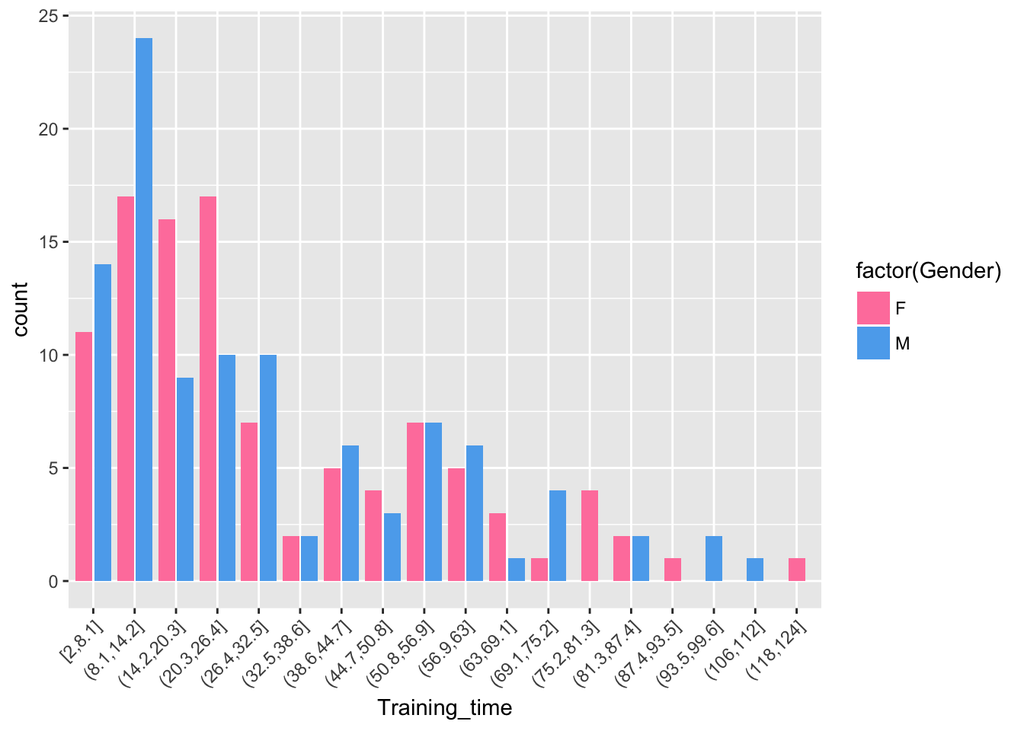

## Votes

### Distribution

```
## [[1]]
## # A tibble: 6 x 2
##   `cut_width(Votes_ep5, range/4)`     n
##                            <fctr> <int>
## 1            [-1.28e+05,1.28e+05]   128
## 2             (1.28e+05,3.85e+05]    41
## 3             (3.85e+05,6.42e+05]    16
## 4             (6.42e+05,8.99e+05]    11
## 5             (8.99e+05,1.16e+06]     1
## 6                            <NA>     7
```

```
## [[1]]
## # A tibble: 2 x 2
##   Gender      mean
##    <chr>     <dbl>
## 1      F  88689.12
## 2      M 252033.34
```

Do people keep voting if their favorite trainees get eliminated? - Top 60 in ep 6 - Top 35 in ep 10 - Top 20/22 in ep 11 Other factors that influece.

# Analysis of relationships

## Age and ranking comparison

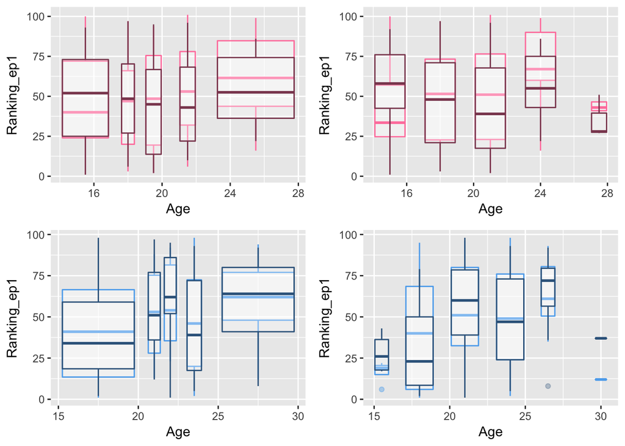

# Judge evaluation

## Comparison of distribution for the two rankings

- Most people in F, least in A
- More people in A for the second time

## Distribution in season 2

- Evaluation increased and least in A class. Probably planned by the show.

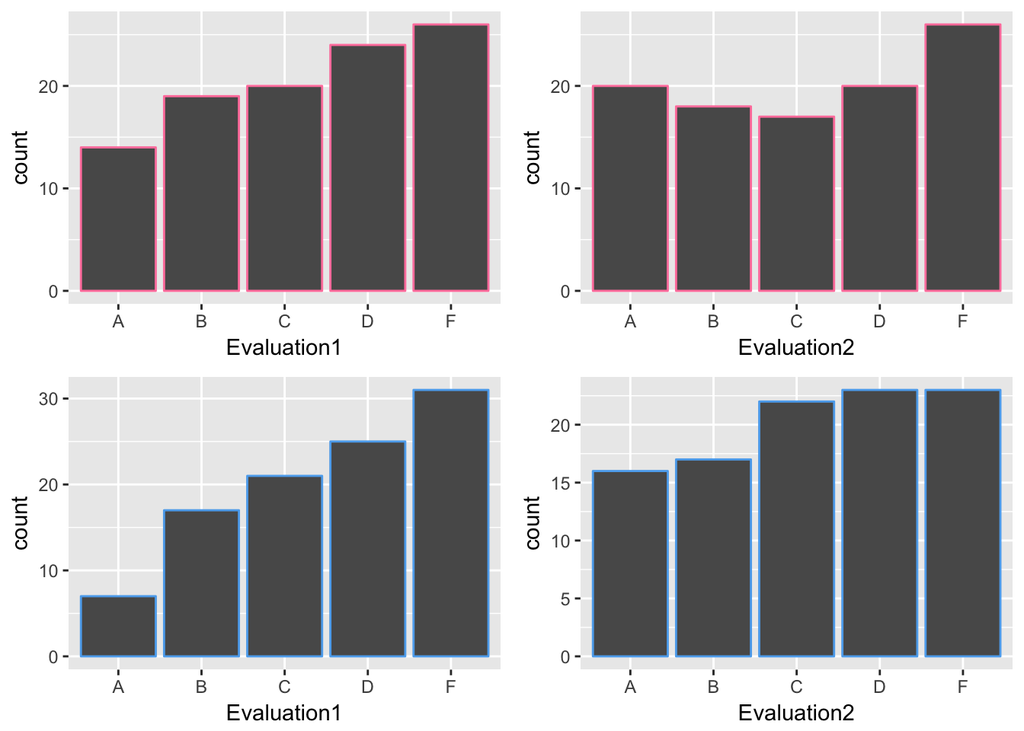

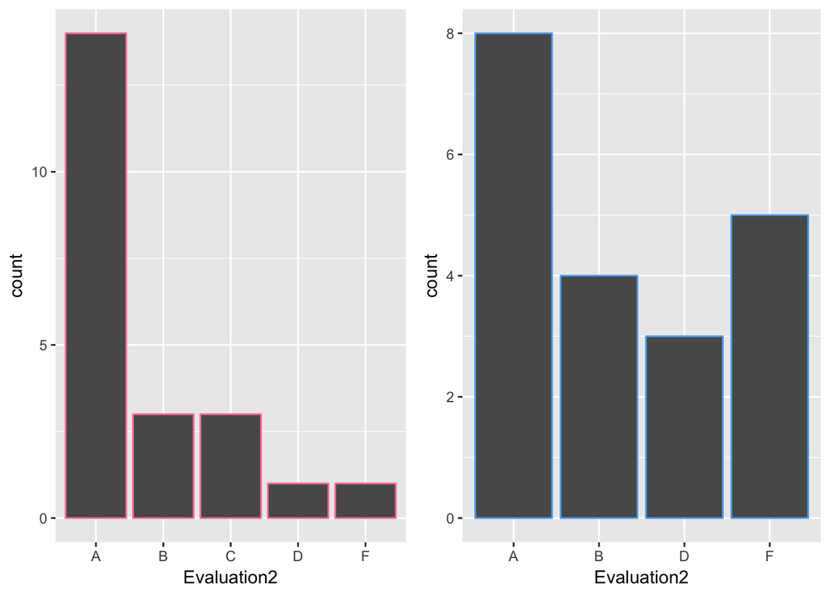

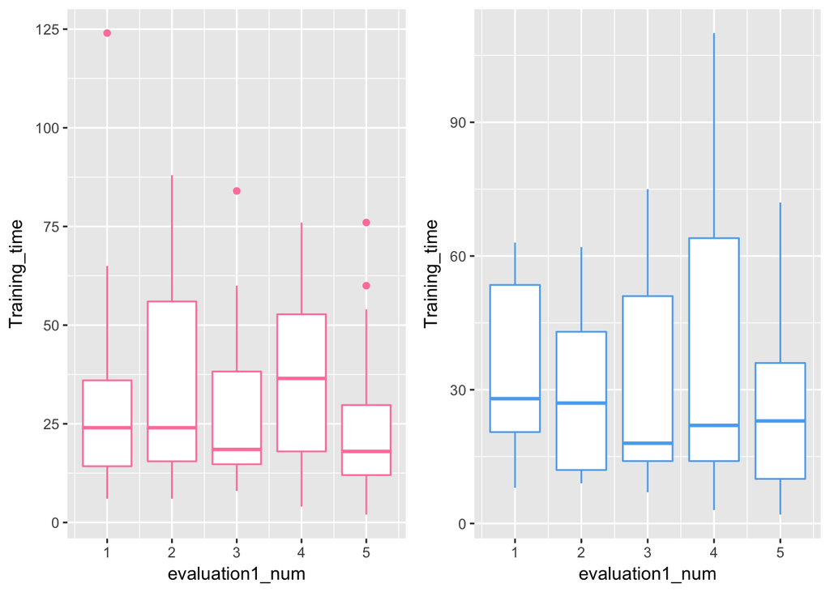

## Rankings and judge evaluation

- A,B,C,D,F
- A(best) = 1, F(worst) = 5

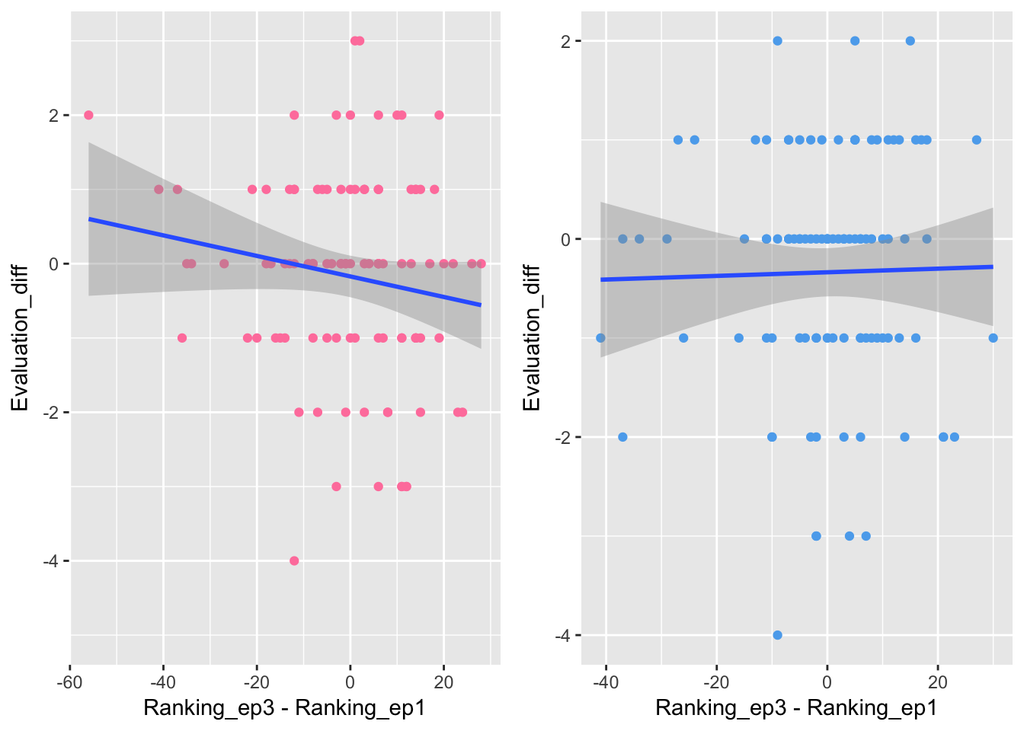

## Group by companies

try use filter to do this…

```
## # A tibble: 11 x 2
## # Groups:   Company [11]
##                     Company     n
##                       <chr> <int>
##  1       Individual Trainee    11
##  2     Pledis Entertainment    11
##  3 Happy Face Entertainment     9
##  4   Blessing Entertainment     7
##  5                 Fantagio     6
##  6      Midas Entertainment     6
##  7       Cube Entertainment     5
##  8        MMO Entertainment     5
##  9     Rainbow Bridge World     5
## 10   Starship Entertainment     5
## 11     Yuehua Entertainment     5
```

```
## # A tibble: 46 x 2
## # Groups:   Company [46]
##                     Company     n
##                       <chr> <int>
##  1 Happy Face Entertainment     9
##  2     Pledis Entertainment     7
##  3       Individual Trainee     6
##  4      Midas Entertainment     6
##  5   Blessing Entertainment     5
##  6                 Fantagio     5
##  7     Kconic Entertainment     4
##  8       Cube Entertainment     3
##  9  Jellyfish Entertainment     3
## 10    LOUDers Entertainment     3
## # ... with 36 more rows
```

```
## # A tibble: 53 x 2
## # Groups:   Company [53]
##                 Company     n
##                   <chr> <int>
##  1   Individual Trainee     5
##  2    MMO Entertainment     5
##  3 Rainbow Bridge World     5
##  4 Yuehua Entertainment     5
##  5      Brand New Music     4
##  6     HF Music Company     4
##  7  I.One Entertainment     4
##  8 Pledis Entertainment     4
##  9       The Vibe Label     4
## 10              YGKPlus     4
## # ... with 43 more rows
```

```
## # A tibble: 12 x 3
## # Groups:   Company [?]
##                   Company Gender `mean(Ranking_final)`
##                     <chr>  <chr>                 <dbl>
##  1 Blessing Entertainment      F              82.60000
##  2 Blessing Entertainment      M              70.50000
##  3     Cube Entertainment      F              38.00000
##  4     Cube Entertainment      M              12.00000
##  5               Fantagio      F              27.00000
##  6               Fantagio      M               5.00000
##  7     Individual Trainee      F              36.50000
##  8     Individual Trainee      M              50.80000
##  9   Pledis Entertainment      F              25.85714
## 10   Pledis Entertainment      M              14.00000
## 11 Starship Entertainment      F              40.33333
## 12 Starship Entertainment      M              28.00000
```

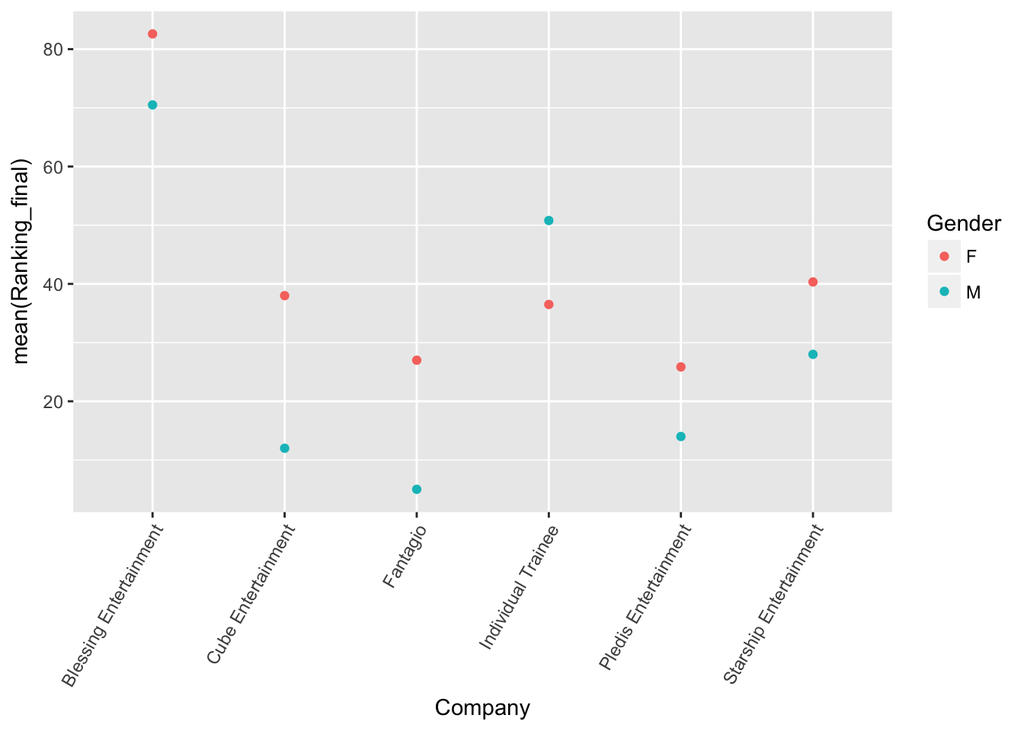

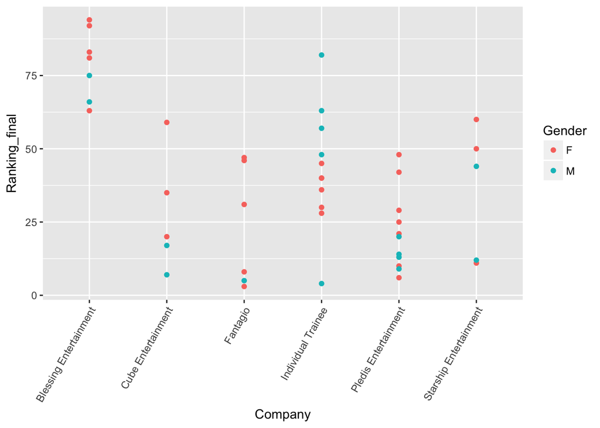

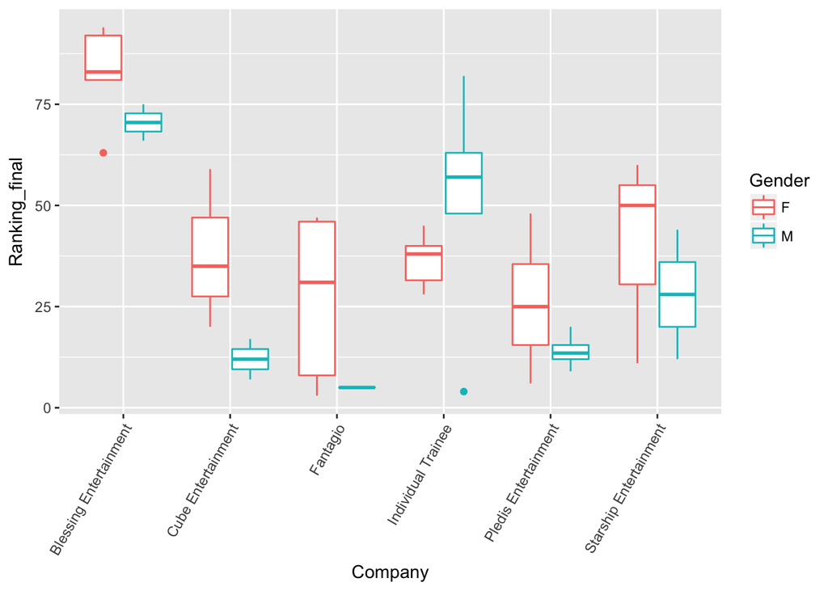

## Weight

# if there’s a big change between the ranking in first episode and last

# female heights

# if company influences ranking: both female and male ranking

# if training time influences ranking

# if when they started training influences ranking

# ggplotly

# slides should be self explanatory

# put web link for produce 101, why explain

# https://www.wattpad.com/209127413-produce-101-profiles-season-1-018-zhou-jieqiong-%E2%98%86

write a method for exploring simple distribution of data https://stackoverflow.com/questions/27773881/r-object-not-found-if-defined-within-a-function-when-using-data-table-dplyr

rlang::UQ(rlang::sym(“cyl”))

eval(parse(text = y))